# HW3 BioStatistics

Alina Bondareva

2024-03-20

# Домашнее задание №3.

### Выполнила Бондарева Алина Кирилловна

В первых двух заданиях необходимо посчитать описательные статистики. Для количественной переменной рассчитайте число наблюдений, среднее, стандартное отклонение, 1-й и 3-й квартили, минимум и максимум. Для категориальной переменной определите абсолютную и относительные частоты.

## Шаг 0: Установка и загрузка необходимых библиотек.

```r
knitr::opts_chunk$set(
    message = FALSE,
    warning = FALSE,
    include = FALSE
)
library(dplyr)
library(ggplot2)
library(readxl)
library(lme4)
library(stats)
```

## Шаг 1. Рассчитайте описательные статистики для переменных `glucose`, `pressure`, `mass`.

```r
pima_data <- read_excel("C:/Users/bonda/Desktop/МФТИ/2 семестр/Биостатистика/ДЗ3/pima.xlsx")
pima_data <- na.omit(pima_data) # удалим все пропущенные значения в строках.
pima_data %>%
  summarise( # Используем функцию summarise() из пакета dplyr для расчета статистик.
    Count_Glucose = n(), # n() возвращаем количество наблюдений.
    Mean_Glucose = mean(glucose, na.rm = TRUE), # mean() используем для расчета среднего значения.
    SD_Glucose = sd(glucose, na.rm = TRUE), # sd() используем для расчета стандартного отклонения.
    Q1_Glucose = quantile(glucose, 0.25, na.rm = TRUE), # quantile() с параметром 0.25 вычисляет первый квартиль.
    Q3_Glucose = quantile(glucose, 0.75, na.rm = TRUE), # quantile() с параметраом 0.75 вычисляет третий квартиль.
    Min_Glucose = min(glucose, na.rm = TRUE),  # min() используем для расчета  минимального значения.
    Max_Glucose = max(glucose, na.rm = TRUE),  # max() используем для расчета  максимального значения.

    Count_Pressure = n(), # n() возвращает количество наблюдений.
    Mean_Pressure = mean(pressure, na.rm = TRUE), # mean() используем для расчета среднего значения.
    SD_Pressure = sd(pressure, na.rm = TRUE), # sd() используем для расчета стандартного отклонения.
    Q1_Pressure = quantile(pressure, 0.25, na.rm = TRUE), # quantile() с параметром 0.25 вычисляет первый квартиль.
    Q3_Pressure = quantile(pressure, 0.75, na.rm = TRUE), # quantile() с параметраом 0.75 вычисляет третий квартиль.
    Min_Pressure = min(pressure, na.rm = TRUE), # min() используем для расчета  минимального значения.
    Max_Pressure = max(pressure, na.rm = TRUE), # max() используем для расчета  максимального значения.

    Count_Mass = n(), # n() возвращает количество наблюдений.
    Mean_Mass = mean(mass, na.rm = TRUE), # mean() используем для расчета среднего значения.
    SD_Mass = sd(mass, na.rm = TRUE), # sd() используем для расчета стандартного отклонения.
    Q1_Mass = quantile(mass, 0.25, na.rm = TRUE), # quantile() с параметром 0.25 вычисляет первый квартиль.
    Q3_Mass = quantile(mass, 0.75, na.rm = TRUE), # quantile() с параметраом 0.75 вычисляет третий квартиль.
    Min_Mass = min(mass, na.rm = TRUE), # min() используем для расчета  минимального значения.
    Max_Mass = max(mass, na.rm = TRUE) # max() используем для расчета  максимального значения.
  )
```

```
## # A tibble: 1 × 21
##   Count_Glucose Mean_Glucose SD_Glucose Q1_Glucose Q3_Glucose Min_Glucose
##           <int>        <dbl>      <dbl>      <dbl>      <dbl>       <dbl>
## 1           768         121.       32.0         99       140.           0
## # ℹ 15 more variables: Max_Glucose <dbl>, Count_Pressure <int>,
## #   Mean_Pressure <dbl>, SD_Pressure <dbl>, Q1_Pressure <dbl>,
## #   Q3_Pressure <dbl>, Min_Pressure <dbl>, Max_Pressure <dbl>,
## #   Count_Mass <int>, Mean_Mass <dbl>, SD_Mass <dbl>, Q1_Mass <dbl>,
## #   Q3_Mass <dbl>, Min_Mass <dbl>, Max_Mass <dbl>
```

## Шаг 2. Рассчитайте описательную статистику для переменной `diabetes`. Создайте на основе переменной `age` новую переменную `age_group`, которая будет отражать следующие возрастные группы: 21–35, 36–49 и 50+. Посчитайте описательную статистику для новой переменной.

```r
# Преобразуем переменную `diabetes` из character в factor:
pima_data <- pima_data %>%
  mutate(diabetes = as.factor(diabetes))
```

```r
# Проведем абсолютный и относительный частотный анализ, а также процентное распределение:
diabetes_stats <- pima_data %>%
  group_by(diabetes) %>%
  summarise(
    Absolute_Frequency = n(), # Абсолютная частота.
    Relative_Frequency = n() / nrow(pima_data) # Относительная частота.
  ) %>%
  mutate(
    Percentage = Relative_Frequency * 100 # Процентное распределение = относительная частрта * 100%.
  )

# Вывод абсолютной и относительной частот, а также процентного распределения.
print(diabetes_stats)
```

```
## # A tibble: 2 × 4
##   diabetes Absolute_Frequency Relative_Frequency Percentage
##   <fct>                 <int>              <dbl>      <dbl>
## 1 neg                     500              0.651       65.1
## 2 pos                     268              0.349       34.9
```

```r
# Создаем новую переменную `age_group`.
pima_data <- pima_data %>%
  mutate(age_group = case_when( # Для категоризации возраста используем функцию mutate() с case_when(), которая позволяет присвоить каждому наблюдению конкретную возрастную группу.
    age >= 21 & age <= 35 ~ "21–35", # Условие, когда возраст находится в диапазоне от 21 до 35 лет включительно, присваивается группа "21–35".
    age >= 36 & age <= 49 ~ "36–49", # Условие, когда возраст находится в диапазоне от 36 до 49 лет включительно, присваивается группа "36–49".
    age >= 50 ~ "50+", # Условие, когда возраст 50 лет и старше, присваивается группа "50+"
    TRUE ~ NA_character_ # Если ни одно из вышеуказанных условий не выполняется, присваивается NA, предусмотрено для полноты картины и "страховки" на случай строки с неожиданным значением возраста.
  ))

# Расчет абсолютных и относительных частот для новой переменной `age_group`.
pima_data %>%
  count(age_group) %>% # Подсчитываем количество записей для каждого уровня в переменной `age_group`.
  # Добавляем новую колонку Frequency_Percentage, рассчитывая относительную частоту для каждой группы.
  mutate(Frequency_Percentage = n / sum(n) * 100) # Процентное значение каждой возрастной группы от общего кол-ва.
```

```
## # A tibble: 3 × 3
##   age_group     n Frequency_Percentage
##   <chr>     <int>                <dbl>
## 1 21–35       498                 64.8
## 2 36–49       181                 23.6
## 3 50+          89                 11.6
```

## Шаг 3. Определите 90% доверительный интервал для переменной `pedigree`.

```r
# Вызываем функцию t.test() для вычисления доверительного интервала для переменной pedigree.
#  Функция t.test() используется для проведения t-теста, однако, если не указывать вторую группу для сравнения, то будет рассчитан доверительный интервал для среднего значения нужной нам выборки.
t_test_result <- t.test(pima_data$pedigree, conf.level = 0.90) # Задаем уровень доверия в 90%.

# Выводим результаты доверительного интервала.
t_test_result$conf.int
```

```
## [1] 0.4521870 0.4915656
## attr(,"conf.level")
## [1] 0.9
```

Этот результат означает, что с 90% вероятностью истинное среднее значение переменной `pedigree` в генеральной совокупности лежит в диапазоне от 0.4521870 до 0.4915656.

## Шаг 4. Постройте график плотности вероятности для переменной `glucose` и отметьте на нем среднее значение. Для той же переменной постройте гистограмму. Постройте два ящика с усами для значений `pos` и `neg` соответственно переменной `diabetes`.

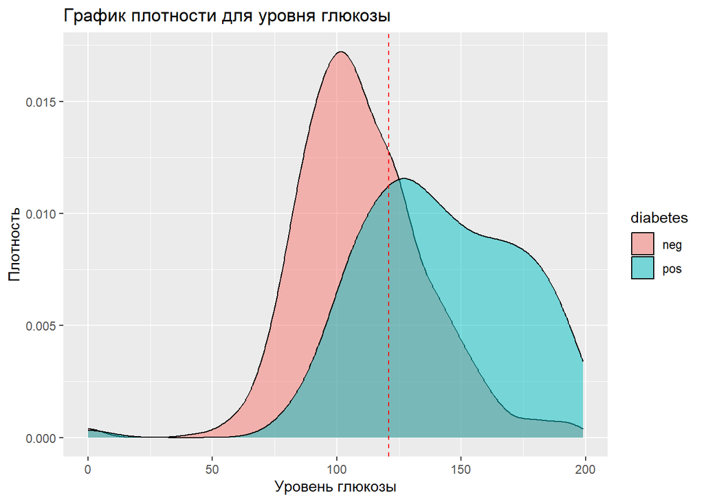

```r
# Построим график плотности для `glucose` с отметкой среднего.
ggplot(pima_data, aes(x = glucose)) +
  # Добавляем слой плотности, окрашиваем в зависимости от наличия диабета.
  geom_density(aes(fill = diabetes), alpha = 0.5) +
  # Добавляем вертикальную линию, обозначающую среднее значение уровня глюкозы.
  geom_vline(aes(xintercept = mean(glucose, na.rm = TRUE)), color = "red", linetype = "dashed") +
  # Задаем названия графика и осей.
  labs(title = "График плотности для уровня глюкозы", x = "Уровень глюкозы", y = "Плотность")
```

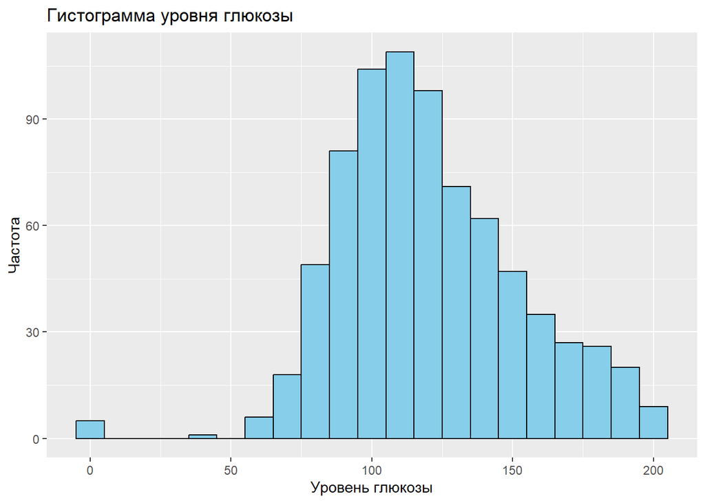

```r
# Построим гистограмму для уровня `glucose`.
ggplot(pima_data, aes(x = glucose)) +
  # Добавляем слой гистограммы с шириной столбцов 10 и цветами...
  geom_histogram(binwidth = 10, fill = "skyblue", color = "black") +
  # Задаем названия графика и осей.
  labs(title = "Гистограмма уровня глюкозы", x = "Уровень глюкозы", y = "Частота")
```

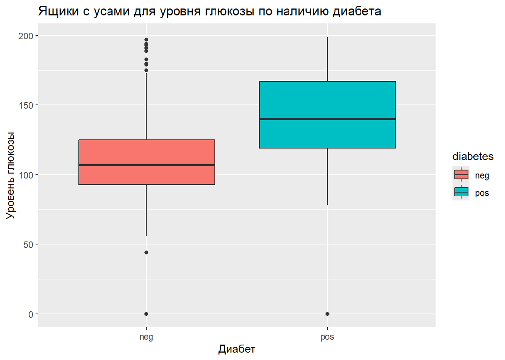

```r
# Создаем ящики с усами для уровня глюкозы, разделяя данные по наличию диабета или отсутствию.
ggplot(pima_data, aes(x = diabetes, y = glucose, fill = diabetes)) +
  # Добавляем ящики с усами.
  geom_boxplot() +
  # Задаем названия графика и осей.
  labs(title = "Ящики с усами для уровня глюкозы по наличию диабета", x = "Диабет", y = "Уровень глюкозы")
```

## Шаг 5. Постройте на одном графике две диаграммы рассеяния для наличия или отсутствия диабета. По оси X представьте значения обхвата трицепса, а по оси Y — массу тела. Выполните окрашивание, заливку и группирование по переменной `diabetes`.

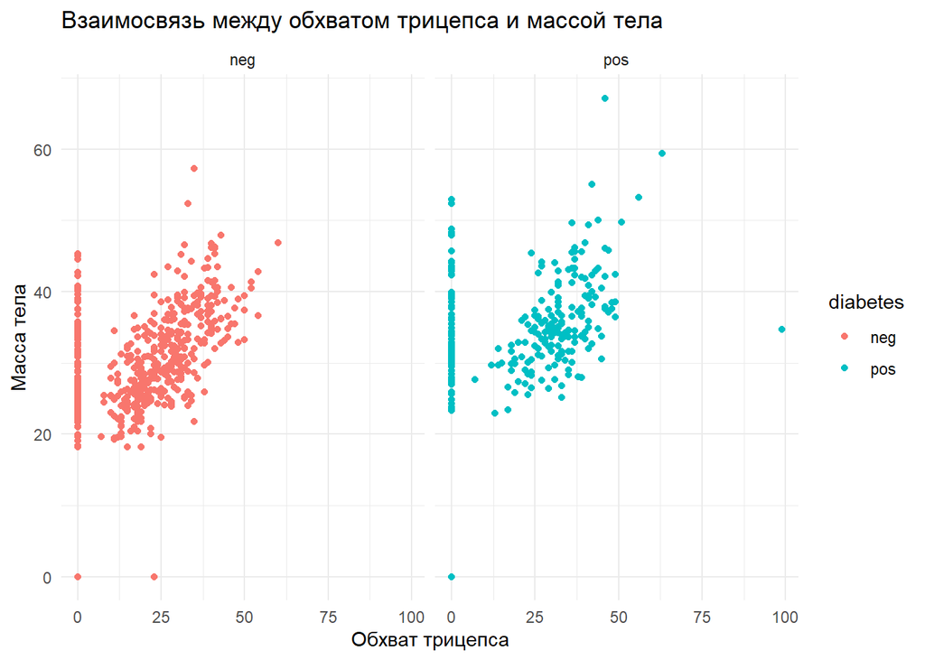

```r
# Построим диаграммы рассеяния для обхвата трицепса и массы тела по переменной `diabetes`.
ggplot(pima_data, aes(x = triceps, y = mass, color = diabetes)) +
  geom_point() +
  facet_grid(. ~ diabetes) +
  labs(title = "Взаимосвязь между обхватом трицепса и массой тела",
       x = "Обхват трицепса", y = "Масса тела") +
  theme_minimal()
```

мы видим много проблем… странные значения массы тела и обхвата трицепса. Давайте приведем в порядок и снова потроим график.

```r
# Определим границы для обхвата трицепса и массы тела в нашем датасете с помощью квантилей. Например, используем 1% и 99% квантили для определения нижней и верхней границ.
triceps_limits <- quantile(pima_data$triceps, probs = c(0.01, 0.99), na.rm = TRUE)
mass_limits <- quantile(pima_data$mass, probs = c(0.01, 0.99), na.rm = TRUE)

# Проводим фильтрацию датафрейма для удаления выбросов и пропущенных значений.
pima_data_clean <- pima_data %>%
  filter(
    triceps > triceps_limits[1] & triceps < triceps_limits[2], # Удаление выбросов в `triceps`.
    mass > mass_limits[1] & mass < mass_limits[2], # Удаление выбросов в mass
    !is.na(triceps), # Удаление пропущенных значений в `triceps`.
    !is.na(mass) # Удаление пропущенных значений в `mass`.
  )
```

Посмотрим снова:

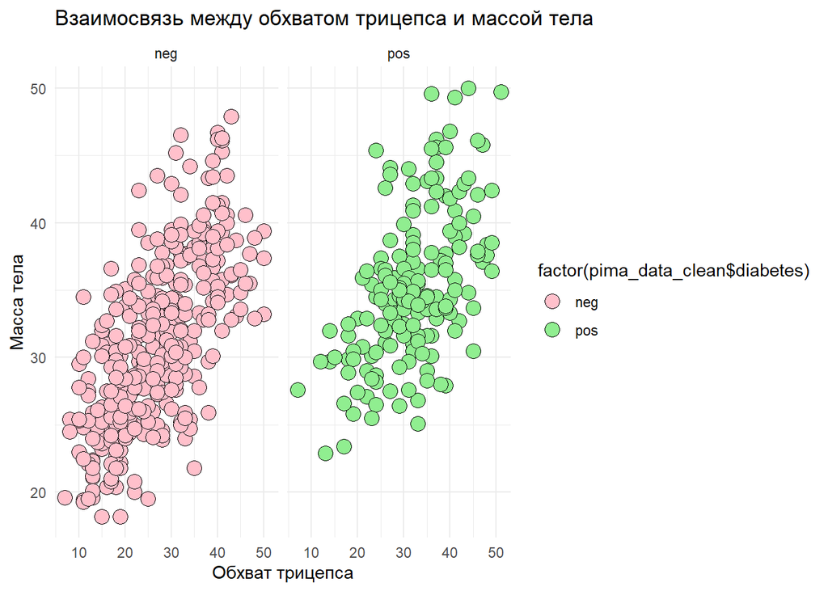

```r
# Построим диаграммы рассеяния для обхвата трицепса и массы тела по переменной `diabetes`.
ggplot(data = pima_data_clean,
                aes(x = triceps, y = mass)) +
  geom_point(color = "black", shape = 21, size = 4,
             aes(fill = factor(pima_data_clean$diabetes))) +
  scale_fill_manual(values = c("pink", "lightgreen")) +
  facet_grid(. ~ diabetes) +
  labs(title = "Взаимосвязь между обхватом трицепса и массой тела",
       x = "Обхват трицепса", y = "Масса тела") +
  theme_minimal()
```